# PGA Tour Driving Distributions

The [Shotlink System](https://shotlink.com/about/history) provides detailed shot-by-shot location data for PGA Tour events, and these data led to many groundbreaking advances in golf analytics.

This notebook explores tee shots and attempts to model the distribution of the location of drives conditioned on individual golfers. Let's explore the data and transform some features to make downstream analysis easier.

```python
%pip install pygam


import pandas as pd
import numpy as np

import plotly.express as px
import matplotlib.pyplot as plt

from pygam import PoissonGAM, te

import pymc as pm
import arviz as az
from scipy.stats import norm

import pickle

import warnings
warnings.filterwarnings('ignore')
```

```python
drive_df = pd.read_csv("/content/drive/MyDrive/Golf/tee.csv")
drive_df
```

|  | strokeId | type | shotNumber | distance | left | from_x | from_y | from_z | groupId | x | ... | pin_x | pin_y | pin_z | fairway_center_x | fairway_center_y | fairway_center_z | hole_number | event_id_hole | course_id | event |
| --- | --- | --- | --- | --- | --- | --- | --- | --- | --- | --- | --- | --- | --- | --- | --- | --- | --- | --- | --- | --- | --- |
| 0 | 216935.0 | SST | 1.0 | 176 yds | 0 in. | 7122.6 | 8352.09 | 2704.507 | 23.0 | 7632.6 | ... | 7632.63 | 8490.98 | 2682.66 | 0.00 | 0.00 | 0.00 | 17 | R2022047 | 538 | 47 |
| 1 | 308578.0 | SST | 1.0 | 179 yds | 46 ft 9 in. | 7122.6 | 8352.09 | 2704.507 | 39.0 | 7650.1 | ... | 7632.63 | 8490.98 | 2682.66 | 0.00 | 0.00 | 0.00 | 17 | R2022047 | 538 | 47 |
| 2 | 250191.0 | SST | 1.0 | 180 yds | 43 ft 3 in. | 7122.6 | 8352.09 | 2704.507 | 6.0 | 7651.9 | ... | 7632.63 | 8490.98 | 2682.66 | 0.00 | 0.00 | 0.00 | 17 | R2022047 | 538 | 47 |
| 3 | 406300.0 | SST | 1.0 | 186 yds | 48 ft 5 in. | 7122.6 | 8352.09 | 2704.507 | 34.0 | 7649.1 | ... | 7632.63 | 8490.98 | 2682.66 | 0.00 | 0.00 | 0.00 | 17 | R2022047 | 538 | 47 |
| 4 | 341760.0 | SST | 1.0 | 166 yds | 42 ft 3 in. | 7122.6 | 8352.09 | 2704.507 | 44.0 | 7608.2 | ... | 7632.63 | 8490.98 | 2682.66 | 0.00 | 0.00 | 0.00 | 17 | R2022047 | 538 | 47 |
| ... | ... | ... | ... | ... | ... | ... | ... | ... | ... | ... | ... | ... | ... | ... | ... | ... | ... | ... | ... | ... | ... |
| 564261 | 386972.0 | SST | 1.0 | 330 yds | 153 yds | 7434.9 | 10215.59 | 356.743 | 19.0 | 8395.0 | ... | 8848.13 | 10049.31 | 352.54 | 8319.55 | 10122.43 | 350.02 | 7 | R2021476 | 513 | 476 |
| 564262 | 410315.0 | SST | 1.0 | 267 yds | 134 yds | 11681.6 | 10946.42 | 337.065 | 19.0 | 11927.2 | ... | 11678.57 | 9870.78 | 331.33 | 11922.45 | 10170.86 | 331.15 | 12 | R2021476 | 513 | 476 |
| 564263 | 368518.0 | SST | 1.0 | 328 yds | 234 yds | 8001.3 | 10331.28 | 363.057 | 19.0 | 7061.5 | ... | 6359.34 | 10587.46 | 342.66 | 7166.72 | 10586.21 | 346.11 | 3 | R2021476 | 513 | 476 |
| 564264 | 374131.0 | SST | 1.0 | 193 yds | 25 ft 3 in. | 6451.8 | 10313.55 | 353.922 | 19.0 | 7028.8 | ... | 7017.51 | 10264.89 | 346.46 | 0.00 | 0.00 | 0.00 | 4 | R2021476 | 513 | 476 |
| 564265 | 406911.0 | SST | 1.0 | 146 yds | 6 ft 3 in. | 12040.3 | 11400.37 | 344.513 | 19.0 | 11753.5 | ... | 11758.22 | 11072.34 | 336.30 | 0.00 | 0.00 | 0.00 | 11 | R2021476 | 513 | 476 |

564266 rows × 39 columns

There's a lot of information in this dataset (and a lot of golf shots! the dataset covers a subset of tracked events from 2020 - 2022 on the PGA Tour), but let's focus on a few key columns and assumptions to set up our analysis:

- `from_x/y/z`: These are the coordinates from where the golf shot takes place. I'm actually not sure of [the actual coordinate system](https://forum.datagolf.com/t/linking-shotlink-data-to-latitude-longitude-coordinates/789), but we'll shift the origin of each shot to `from_x/y/z` to ensure a consistent coordinate system across shots
- `x/y/z`: These are the coordinates of where the golf shot ends up (taking the Euclidean distance from the `from_x/y/z` points to this point results in the `distance` column)
- `fairway_center_x/y/z`: Another set of coordinates, but these aptly named fields locate the center of the fairway

This last location is the key. In addition to shifting the origin of each shot to the tee box (`from_x/y/z`), the following rotates the coordinate system so that the y-axis intersects with the fairway center. The implicit assumption here is that golfers by-and-large aim towards the center of the fairway, so the analysis may be biased by some holes being constructed in such a way where aiming off-center would be more valuable.

Lastly, to guard against golfers using clubs other than their driver, we'll limit the analysis to consider par-5 holes (which should, in theory, help with the aiming assumption above).

## Transformation

After the par-5 filter, the `transform_coordinate_system` performs the translation of the origin of the coordinate system to the tee box and rotates the axes so that the y-axis intersects the center of the fairway.

The translation is straight forward, but the rotation leverages the angle $\theta$ between the vector in the old coordinate system ($A$) and the new coordinate system ($B$):

$$ \theta = \text{arccos}(\frac{A \cdot B}{||A||||B||}) $$

Then, the [rotation](https://motion.cs.illinois.edu/RoboticSystems/CoordinateTransformations.html) is simply given by:

$$ B = \begin{bmatrix} \text{cos}(\theta) & -\text{sin}(\theta) \\ \text{sin}(\theta) & \text{cos}(\theta) \end{bmatrix} A $$

```python
drive_df = drive_df[drive_df["par"]==5]
```

```python
def transform_coordinate_system(drive_df: pd.DataFrame) -> pd.DataFrame:
    """ This function transforms the coordinate system for each shot
    so that the origin is at the tee box, and the y-axis intersects
    the center of the fairway

    @param drive_df (pd.DataFrame): DataFrame containing shot and
        hole locations in the original coordinate system
    @return drive_df (pd.DataFrame): DataFrame containing shot and
        hole locations in the new coordinate system
    """

    # Translation
    ## Initial rotation booleans
    initial_rotation_x = [x > fairway_x for x, fairway_x in zip(drive_df["from_x"], drive_df["fairway_center_x"])]
    initial_rotation_y = [y > fairway_y for y, fairway_y in zip(drive_df["from_y"], drive_df["fairway_center_y"])]
    ## Ball location after drive
    drive_df["x"] = drive_df["x"] - drive_df["from_x"]
    drive_df["y"] = drive_df["y"] - drive_df["from_y"]
    drive_df["z"] = drive_df["z"] - drive_df["from_z"]

    ## Fairway center
    drive_df["fairway_center_x"] = drive_df["fairway_center_x"] - drive_df["from_x"]
    drive_df["fairway_center_y"] = drive_df["fairway_center_y"] - drive_df["from_y"]
    drive_df["fairway_center_z"] = drive_df["fairway_center_z"] - drive_df["from_z"]

    ## This negates the coordinates based on the location of the
    #tee box relative to the fairway center
    drive_df["x"] = [-x if rotate else x for x, rotate in zip(drive_df["x"], initial_rotation_x,)]
    drive_df["y"] = [-y if rotate else y for y, rotate in zip(drive_df["y"], initial_rotation_y,)]
    drive_df["fairway_center_x"] = [-x if rotate else x for x, rotate in zip(drive_df["fairway_center_x"], initial_rotation_x,)]
    drive_df["fairway_center_y"] = [-y if rotate else y for y, rotate in zip(drive_df["fairway_center_y"], initial_rotation_y,)]
    drive_df["rotate_x"] = initial_rotation_x
    drive_df["rotate_y"] = initial_rotation_y

    # Rotation
    ## Fairway center distance - this sets the location of the fairway center
    # of x = 0 and y as the two-dimensional distance from the tee box in the
    # x-y plane
    drive_df["fairway_center_new_y"] = np.sqrt(
        drive_df["fairway_center_x"]**2 + drive_df["fairway_center_y"]**2
    )
    drive_df["fairway_center_new_x"] = 0

    # Angle numerator
    drive_df["angle_numerator"] = [
        np.dot(np.array([x, y]), np.array([new_x, new_y]).T) for x, y, new_x, new_y in zip(
            drive_df["fairway_center_x"],
            drive_df["fairway_center_y"],
            drive_df["fairway_center_new_x"],
            drive_df["fairway_center_new_y"]
        )
    ]
    # Angle denominator
    drive_df["angle_denominator"] = [
        np.linalg.norm(np.array([x, y])) * np.linalg.norm(np.array([new_x, new_y])) for x, y, new_x, new_y in zip(
            drive_df["fairway_center_x"],
            drive_df["fairway_center_y"],
            drive_df["fairway_center_new_x"],
            drive_df["fairway_center_new_y"]
        )
    ]

    # Angle of rotation
    drive_df["fairway_angle"] = np.arccos(
        drive_df["angle_numerator"]
    / drive_df["angle_denominator"]
    )

    # Rotate coordinate system
    drive_df["x_new"] = (drive_df["x"]*np.cos(drive_df["fairway_angle"]) - drive_df["y"]*np.sin(drive_df["fairway_angle"]))
    drive_df["y_new"] = (drive_df["x"]*np.sin(drive_df["fairway_angle"]) + drive_df["y"]*np.cos(drive_df["fairway_angle"]))

    drive_df["x_new"] = [
        -x if (rotate and not rotate_y) else
        -x if (rotate_y and not rotate) else
        x for x, rotate, rotate_y in zip(drive_df["x_new"], initial_rotation_x, initial_rotation_y)
    ]

    return drive_df
```

```python
drive_df = transform_coordinate_system(drive_df)
```

Armed with the transformed coordinates of drive locations, let's visualize them. We'll convert from feet (the original units of the coordinates) to yards and limit the axes to realistic locations for drives.

```python
drive_df["x_new"] = drive_df["x_new"]/3
drive_df["y_new"] = drive_df["y_new"]/3
```

[figure not shown]

```python
# Location coordinates
fig, ax = plt.subplots()
ax.scatter(drive_df["x_new"], drive_df["y_new"], alpha=0.1)

# Add fairway edge
plt.vlines(30, 0, 500, 'k', '--')
plt.vlines(-30, 0, 500, 'k', '--')
plt.annotate("Fairway Edge", (32, 450))
plt.ylim(0, 500)
plt.xlim(-250, 250)

# Update title and axes
plt.title("PGA Tour Drive Locations")
plt.ylabel("y-coordinates (yds)")
plt.xlabel("x-coordinates (yds)")

plt.show()
```

This seems pretty reasonable!

- Outside of some clear outliers, the majority of shot locations center around the fairway center at about 300 yds from the tee box
- The ranges in both dimensions make sense, with the drives ranging from 250 to 400 yds in the y-dimension and -60 to 60 yards in the x-dimension
  - I overlayed "fairway edges" to create a fairway 60 yds wide
- There are some short shots that don't appear to be drives. Without club or more detailed hole information, filtering these out of the analysis below is a quick-and-dirty way to proceed.

We should be ready to proceed with modeling.

## Model

Because we're interested in modeling the distribution of drives for each golfer, a hierarchical model seems like a natural way to approach the problem. More formally, for each golf shot $i$ by golfer $j$, we'll start simply by modeling the drive location $D$ as a Multivariate Normal distribution with mean $\mu$ and covariance $\Sigma$ with the x- and y-coordinates of location assumed to be independent:

$$ \begin{align} D_i \sim N(\mu, \Sigma) \\ \mu = \begin{bmatrix} \mu_{x_j} \\ \mu_{y_j} \end{bmatrix} \\ \Sigma = \begin{bmatrix} \sigma_{x_j}^2 && 0 \\ 0 && \sigma_{y_j}^2 \\ \end{bmatrix} \\ \mu_{x_j}, \mu_{y_j} \sim N(0, 1) \\ \sigma_{x_j}, \sigma_{y_j} \sim \text{Exp}(1) \end{align} $$

```python
# Quick-and-dirty data quality / lack-of-club information filter
drive_df = drive_df[
    (abs(drive_df["x_new"])<=150) &
    (drive_df["y_new"]<=500) &
    (drive_df["y_new"]>=200)
]

# Standardizing the location coordinates to mean 0 and variance 1
drive_df["x_scaled"] = (drive_df["x_new"] - drive_df["x_new"].mean())/drive_df["x_new"].std()
drive_df["y_scaled"] = (drive_df["y_new"] - drive_df["y_new"].mean())/drive_df["y_new"].std()
```

```python
# Create golfer factors and store the coordinate dimensions
player_idxs, players = pd.factorize(drive_df["player_id"])
coords = {
    "players": players,
    "obs_id": np.arange(len(player_idxs)),
    "coordinates": ["x", "y"]
}

with pm.Model(coords=coords) as mdl:

    # Set player indices
    player_idx = pm.Data("player_idx", player_idxs, dims="obs_id")

    # define priors, weakly informative
    ## mean
    mu = pm.Normal("mu", mu=0, sigma=1, dims=("players", "coordinates"))
    ## std
    sigma = pm.Exponential("sigma", lam=1, dims=("players", "coordinates"))

    ## Define Multivariate likelihood
    d = pm.Normal("d", mu=mu[player_idx], sigma=sigma[player_idx], observed=np.array(drive_df[["x_scaled", "y_scaled"]]))
```

```python
pm.model_to_graphviz(mdl)
```

[figure not shown]

A visual inspection of the model structure confirms we've set it up properly. Player effects (733 players) for both the mean and variance parameters for the two location coordinates feed into a Normal likelihood.

With that, we'll use variational inference in place of Markov Chain Monte Carlo sampling for speed purposes, but still do due diligence in assessing model performance and diagnostics.

```python
with mdl:
    advi = pm.ADVI()
```

```python
tracker = pm.callbacks.Tracker(
    mean=advi.approx.mean.eval,  # callable that returns mean
    std=advi.approx.std.eval,  # callable that returns std
)
approx = advi.fit(10000, callbacks=[tracker])
```

```
Output()
```

## Validation

With the model fit, the following takes 2000 samples from the posterior distribution of parameters and produces a summary of each.

```python
trace = approx.sample(2000)
summary_df = az.summary(trace.posterior, kind="stats")
summary_df
```

|  | mean | sd | hdi_3% | hdi_97% |
| --- | --- | --- | --- | --- |
| mu[35506, x] | -0.062 | 0.143 | -0.328 | 0.203 |
| mu[35506, y] | -0.058 | 0.144 | -0.331 | 0.208 |
| mu[49771, x] | -0.017 | 0.140 | -0.277 | 0.243 |
| mu[49771, y] | 0.010 | 0.140 | -0.248 | 0.282 |
| mu[27936, x] | 0.127 | 0.143 | -0.140 | 0.403 |
| ... | ... | ... | ... | ... |
| sigma[48640, y] | 1.989 | 0.613 | 0.991 | 3.120 |
| sigma[33968, x] | 0.704 | 0.205 | 0.342 | 1.061 |
| sigma[33968, y] | 1.938 | 0.494 | 1.024 | 2.804 |
| sigma[30909, x] | 1.152 | 0.540 | 0.346 | 2.079 |
| sigma[30909, y] | 2.172 | 0.806 | 0.907 | 3.673 |

2932 rows × 4 columns

This table gives the mean, standard deviation, and 94% highest density interval for each parameter. And, to highlight an example, let's highlight a particular golfer's parameters:

```python
summary_df.loc[
    ["mu[28237, x]",
     "mu[28237, y]",
     "sigma[28237, x]",
     "sigma[28237, y]",
    ]
]
```

|  | mean | sd | hdi_3% | hdi_97% |
| --- | --- | --- | --- | --- |
| mu[28237, x] | 0.014 | 0.147 | -0.250 | 0.305 |
| mu[28237, y] | 0.872 | 0.164 | 0.585 | 1.201 |
| sigma[28237, x] | 1.286 | 0.181 | 0.945 | 1.613 |
| sigma[28237, y] | 1.074 | 0.161 | 0.794 | 1.378 |

Indeed, a quick check of [pgatour.com](https://www.pgatour.com/) confirms this. McIlroy ranked second among qualified players in terms of [driving distance](https://www.pgatour.com/stats/detail/101) in the 2024 season, while he ranked 102nd in terms of [driving accuracy percentage](https://www.pgatour.com/stats/detail/102) and 92nd in a more direct comparison for this study: [distance from the fairway center](https://www.pgatour.com/stats/detail/02421), which considers par-5 and par-4 holes on which the player did not go for the green.

While this anecdote provides some comfort, a more comprehensive validation of the model is necessary to provide evidence that it captures the data generating process well. The following validation steps include:

- **Trace Plots**: Visualizations of the distribution of parameters of interest can help confirm that the distributions are reasonable or help uncover issues with sampling or model structure
- **Posterior Predictive Checks**: To check that predictions from our model are well-calibrated, posterior predictive checks compare the posterior predictive distribution to the distribution of the output data (distance coordinates, in this case). In theory, these distributions should look very similar

```
array([[<Axes: title={'center': 'mu'}>, <Axes: title={'center': 'mu'}>],
       [<Axes: title={'center': 'sigma'}>,
        <Axes: title={'center': 'sigma'}>]], dtype=object)
```

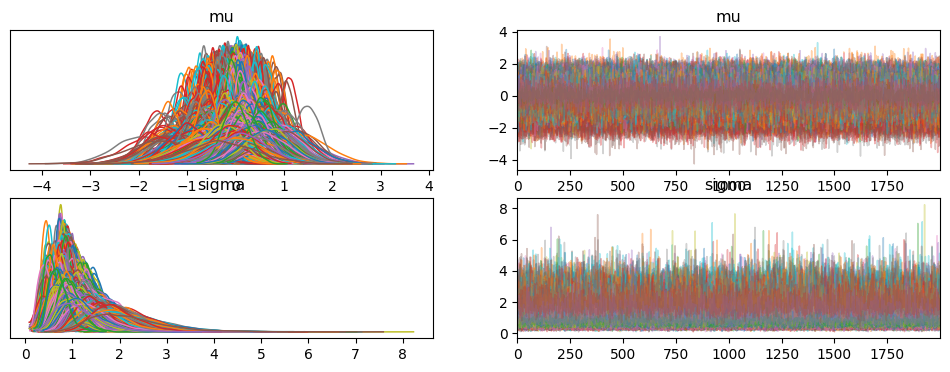

```python
az.plot_trace(trace)
```

The distributions for the player effects appear reasonable, with the means centered around 0 in the aggregate and mostly ranging between +/- two standard deviations. The standard deviations also cluster around their prior mean of 1, but showcase some spread as well.

The trace plots to the right also indicate ADVI performed reasonably, with sufficient mixing and no signs of autocorrelation.

```
Output()
```

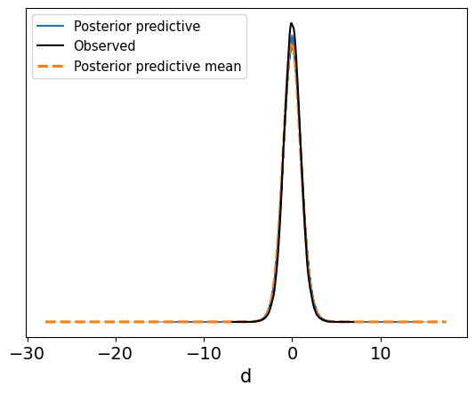

```python
posterior_predictive = pm.sample_posterior_predictive(trace, model=mdl)
az.plot_ppc(posterior_predictive)
```

The posterior predictive distribution tracks the distribution of observed data quite well. To nitpick, the tails of the posterior predictive distribution look a bit thicker than those of the observed data, but not enough to warrant concern.

## Case Study

To highlight the potential uses of this model (or a similar model that scales across all clubs and hole types), the following walks through a case study for two golfers at opposite ends of the spectrum when it comes to driving the golf ball. Bryson DeChambeau famously sells out for distance as this approach generally correlates with higher expected strokes gained off-the-tee, but comes at the cost of accuracy. Jim Furyk has had a tremendous career with pretty much the opposite style of shorter-than-average but very accurate drives.

But, what does the distribution of their drive locations actually look like, and how do the differences manifest themselves through the lens of expected strokes gained? The case study below dives into these questions through the following steps:

- **Visualization**: Comparing the distribution of both golfer's actual drive locations and their predicted drive locations should give an appreciation of the differences between each golfer's drives and the ability of the model to capture those differences
- **Analysis**: Using some basic strokes-gained models for [off-the-tee](https://basketballrelativity.github.io/personal/driving) and approach shots, the distribution of drive locations can be transformed into a distribution of expected strokes gained, allowing us to place a value (and the uncertainty surrounding that value) on each golfer's driving skill

### Visualization

To access each golfer's parameters, the following takes the posterior samples and tracks down the data indexed by DeChambeau's and Furyk's ID.

```python
# Grab the posterior data
posterior_data = trace.posterior.stack(chain_draw=("chain", "draw"))

# Obtain parameters indexed by golfer
hier_mu_est = posterior_data["mu"].transpose("players", ...)
hier_sigma_est = posterior_data["sigma"].transpose("players", ...)

# Indices for Furyk (id == 10809) and DeChambeau (id == 47959)
furyk_idx = np.where(players==10809)
dechambeau_idx = np.where(players==47959)
```

Now, to obtain a posterior distribution of each golfer's drive locations, we'll sample one coordinate pair for each posterior sample of the golfer's mean and variance parameters.

```python
# Sampling Furyk coordinates
furyk_x = norm.rvs(hier_mu_est[furyk_idx][0][0],
                   hier_sigma_est[furyk_idx][0][0])
furyk_y = norm.rvs(hier_mu_est[furyk_idx][0][1],
                   hier_sigma_est[furyk_idx][0][1])

# Sampling DeChambeau coordinates
dechambeau_x = norm.rvs(hier_mu_est[dechambeau_idx][0][0],
                   hier_sigma_est[dechambeau_idx][0][0])
dechambeau_y = norm.rvs(hier_mu_est[dechambeau_idx][0][1],
                   hier_sigma_est[dechambeau_idx][0][1])
```

```python
# Store posterior coordinates in a DataFrame
viz_df = pd.DataFrame({
    "x": np.concatenate((dechambeau_x, furyk_x)),
    "y": np.concatenate((dechambeau_y, furyk_y)),
    "name": ["DeChambeau"]*len(dechambeau_x) + ["Furyk"]*len(furyk_x)
})

# Inverse transform the standardized coordinates
viz_df["x"] = (viz_df["x"] * drive_df["x_new"].std()) + drive_df["x_new"].mean()
viz_df["y"] = (viz_df["y"] * drive_df["y_new"].std()) + drive_df["y_new"].mean()
```

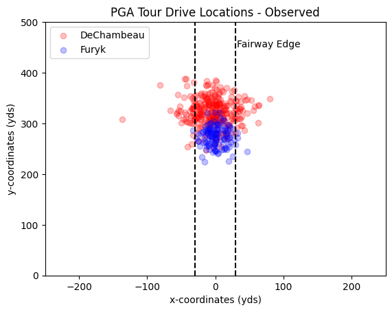

```python
# Observed data
fig, ax = plt.subplots()
ax.scatter(drive_df[drive_df["last_name"]=="DeChambeau"]["x_new"],
           drive_df[drive_df["last_name"]=="DeChambeau"]["y_new"], alpha=0.25, color="red",
           label="DeChambeau")
ax.scatter(drive_df[drive_df["last_name"]=="Furyk"]["x_new"],
           drive_df[drive_df["last_name"]=="Furyk"]["y_new"], alpha=0.25, color="blue",
           label="Furyk")

# Fairway edge
plt.vlines(30, 0, 500, 'k', '--')
plt.vlines(-30, 0, 500, 'k', '--')
plt.annotate("Fairway Edge", (32, 450))
plt.ylim(0, 500)
plt.xlim(-250, 250)

# Update axes and title
plt.title("PGA Tour Drive Locations - Observed")
plt.ylabel("y-coordinates (yds)")
plt.xlabel("x-coordinates (yds)")

ax.legend(loc="upper left")
plt.show()
```

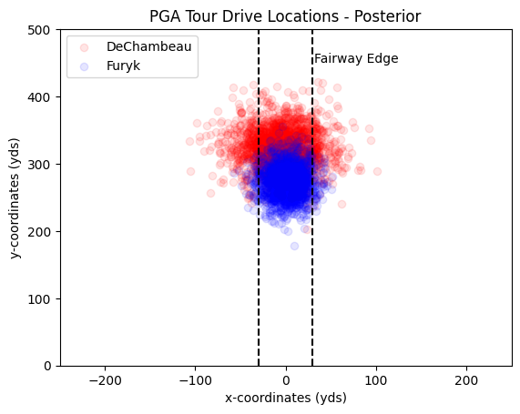

```python
# Posterior data
fig, ax = plt.subplots()
ax.scatter(viz_df[viz_df["name"]=="DeChambeau"]["x"],
           viz_df[viz_df["name"]=="DeChambeau"]["y"], alpha=0.1, color="red",
           label="DeChambeau")
ax.scatter(viz_df[viz_df["name"]=="Furyk"]["x"],
           viz_df[viz_df["name"]=="Furyk"]["y"], alpha=0.1, color="blue",
           label="Furyk")

# Fairway edge
plt.vlines(30, 0, 500, 'k', '--')
plt.vlines(-30, 0, 500, 'k', '--')
plt.annotate("Fairway Edge", (32, 450))
plt.ylim(0, 500)
plt.xlim(-250, 250)

# Update axes and title
plt.title("PGA Tour Drive Locations - Posterior")
plt.ylabel("y-coordinates (yds)")
plt.xlabel("x-coordinates (yds)")

ax.legend(loc="upper left")
plt.show()
```

The posterior and observed data distributions seem like they track each other quite well! There appears to be slightly more spread in the posterior data distribution, but this is likely due to the model's reflection of uncertainty: the posterior samples account for the underlying uncertainty in each player's parameters, which propagates to the posterior draws of location coordinates.

### Expected Strokes Gained

Armed with the posterior distribution of locations for each golfer, feeding them through an expected strokes gained model framework can provide insight into how much value these two golfers realize off-the-tee.

To make this tractable, we'll make a few simplifying assumptions:

- These golfers are playing a 550 yard par-5 with the hole directly on the y-axis (coordinates (0, 550))
- The fairway is 60 yards wide, bordered by rough elsewhere.

The first assumption means we only need one expected strokes value from an off-the-tee model, which we'll load in and predict here.

```python
with open('/content/drive/MyDrive/Golf/drive_models.pkl', 'rb') as handle:
    models = pickle.load(handle)
```

```python
off_the_tee_x_strokes = models["par_5"].predict(np.array(550).reshape(1, -1))[0]
off_the_tee_x_strokes
```

```
4.587147369591772
```

Pretty easy! Getting expected strokes on approach requires a bit more processing, but we already have the location data, so it's mostly an exercise in transforming data and enforcing our assumptions about the size and structure of the hole.

```python
with open('/content/drive/MyDrive/Golf/approach_objs.pkl', 'rb') as handle:
    objs = pickle.load(handle)
```

```python
# One-hot booleans for the lies
viz_df["fairway"] = [1 if abs(val)<30 else 0 for val in viz_df["x"]]
viz_df["rough"] = [1 if abs(val)>=30 else 0 for val in viz_df["x"]]
viz_df["native_area"] = [0 for val in viz_df["x"]]
viz_df["bunker"] = [0 for val in viz_df["x"]]
viz_df["other"] = [0 for val in viz_df["x"]]

# Distance from the hole
viz_df["distance"] = np.sqrt(viz_df["x"]**2 + (550 - viz_df["y"])**2)
viz_df["distance_norm"] = objs["distance_scaler"].transform(viz_df["distance"].values.reshape(-1, 1))
```

Okay, we have all of the model features, so now we can predict the expected number of strokes to hole out and derive strokes gained off-the-tee by taking the difference between this value and the expected number of strokes to hole-out on a 550 yard par-5 from the tee box.

```python
# Predict and store expected strokes
preds = objs["model"].predict(viz_df[["distance_norm", "fairway", "rough", "bunker", "native_area", "other"]])
viz_df["preds"] = preds
viz_df
```

|  | x | y | name | fairway | rough | native_area | bunker | other | distance | distance_norm | preds |
| --- | --- | --- | --- | --- | --- | --- | --- | --- | --- | --- | --- |
| 0 | 32.578225 | 306.117742 | DeChambeau | 0 | 1 | 0 | 0 | 0 | 246.048565 | 1.817405 | 3.576645 |
| 1 | -5.320748 | 255.663664 | DeChambeau | 1 | 0 | 0 | 0 | 0 | 294.384424 | 2.775468 | 3.637455 |
| 2 | 29.477522 | 337.546132 | DeChambeau | 1 | 0 | 0 | 0 | 0 | 214.489091 | 1.191865 | 3.274142 |
| 3 | -71.668675 | 347.617722 | DeChambeau | 0 | 1 | 0 | 0 | 0 | 214.697427 | 1.195995 | 3.473314 |
| 4 | -10.033188 | 305.613631 | DeChambeau | 1 | 0 | 0 | 0 | 0 | 244.592236 | 1.788539 | 3.438736 |
| ... | ... | ... | ... | ... | ... | ... | ... | ... | ... | ... | ... |
| 3995 | -18.943792 | 273.310043 | Furyk | 1 | 0 | 0 | 0 | 0 | 277.337699 | 2.437586 | 3.584840 |
| 3996 | 5.452830 | 266.912537 | Furyk | 1 | 0 | 0 | 0 | 0 | 283.139974 | 2.552592 | 3.604653 |
| 3997 | 17.601837 | 252.417896 | Furyk | 1 | 0 | 0 | 0 | 0 | 298.102220 | 2.849159 | 3.646764 |
| 3998 | 13.856000 | 278.288602 | Furyk | 1 | 0 | 0 | 0 | 0 | 272.064464 | 2.333065 | 3.565043 |
| 3999 | -22.803212 | 268.886047 | Furyk | 1 | 0 | 0 | 0 | 0 | 282.037304 | 2.530736 | 3.601043 |

4000 rows × 11 columns

```python
# Strokes gained off-the-tee (minus one accounts for the actual stroke)
viz_df["strokes_gained"] = off_the_tee_x_strokes - viz_df["preds"] - 1
viz_df.groupby(["name"])["strokes_gained"].agg(["mean", "std"])
```

| name | mean | std |
| --- | --- | --- |
| DeChambeau | 0.196269 | 0.154952 |
| Furyk | 0.013504 | 0.082126 |

On a hole like this, DeChambeau would be expected to be nearly two tenths-of-a-stroke better than Furyk over the time period this dataset covers. And, this indeed checks out. DeChambeau led the PGA Tour in [strokes gained off-the-tee](https://www.pgatour.com/stats/detail/02567) in two of the three seasons in this dataset, while Jim Furyk was slightly below average. Of course, strokes gained off-the-tee also considers par-4 holes and holes of different topology and hazards, so this two tenths-of-a-stroke expected advantage may vary considerably as circumstances change. Indeed, even on this hole, the standard deviation of DeChambeau's expected strokes gained is almost double that of Furyk's.

But, that's just the expected value of strokes gained. Let's visualize strokes gained as a function of location of the posterior samples of both golfers' drives.

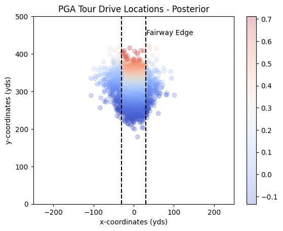

```python
# Posterior data
fig, ax = plt.subplots()
s = ax.scatter(viz_df["x"],
           viz_df["y"], alpha=0.25, c=viz_df["strokes_gained"],
           cmap="coolwarm")
fig.colorbar(s)

# Fairway edge
plt.vlines(30, 0, 500, 'k', '--')
plt.vlines(-30, 0, 500, 'k', '--')
plt.annotate("Fairway Edge", (32, 450))
plt.ylim(0, 500)
plt.xlim(-250, 250)

# Update axes and title
plt.title("PGA Tour Drive Locations - Posterior")
plt.ylabel("y-coordinates (yds)")
plt.xlabel("x-coordinates (yds)")

plt.show()
```

This visualization matches intuition fairly well, with the highest strokes gained values being realized on long drives down the fairway and negative or average values being shorter drives or those in the rough.

## Conclusion

This notebook took a tour through deriving the parameters of a golfer's distribution of drive locations in two-dimensions on par-5 holes and explored a case study that sampled drive locations for two golfers and fed them through expected strokes models to investigate the value of different driving approaches. But, of course, there's much more one can do with these data and concepts:

- **Incorporate club information**: Knowing the type of club a player uses off-the-tee would allow for the extension of the hierarchical model above to incorporate player-club effects. This would reduce the need to filter out data and open the door to expand the model to cover par-4 holes
- **Move beyond the tee**: Even without club information, a similar methodology can be deployed when the golfer is in range of the green with the assumption that they are aiming directly for the hole (which may be dubious). Additional considerations to control for distance and lie would be necessary, but a model similar to the one developed above could provide insights in different areas of the game
- **Hole simulation**: With a full suite of shot distribution and strokes gained models, one could simulate holes with different clubs or even different strategies to determine the combination to maximize srokes gained (or even limit downside risk)